# Risk Factor Analysis

## Outcome Variable

**Outcome Variable:** wast_rec90d

## Predictor Variables

**Intervention Variable:** mhtcm

**Adjustment Set:**

- arm
- W_mage
- meducyrs
- feducyrs
- delta_W_mage
- delta_meducyrs
- delta_feducyrs

## Stratifying Variables

The analysis was stratified on these variable(s):

- agecat
- studyid
- country

## Data Summary

| agecat | studyid | country | mhtcm | wast_rec90d | n_cell | n |
| --- | --- | --- | --- | --- | --- | --- |
| 0-24 months | ki0047075b-MAL-ED | BANGLADESH | >=155 cm | 0 | 4 | 122 |
| 0-24 months | ki0047075b-MAL-ED | BANGLADESH | >=155 cm | 1 | 5 | 122 |
| 0-24 months | ki0047075b-MAL-ED | BANGLADESH | <151 cm | 0 | 33 | 122 |
| 0-24 months | ki0047075b-MAL-ED | BANGLADESH | <151 cm | 1 | 51 | 122 |
| 0-24 months | ki0047075b-MAL-ED | BANGLADESH | [151-155) cm | 0 | 7 | 122 |
| 0-24 months | ki0047075b-MAL-ED | BANGLADESH | [151-155) cm | 1 | 22 | 122 |
| 0-24 months | ki0047075b-MAL-ED | BRAZIL | >=155 cm | 0 | 5 | 23 |
| 0-24 months | ki0047075b-MAL-ED | BRAZIL | >=155 cm | 1 | 12 | 23 |
| 0-24 months | ki0047075b-MAL-ED | BRAZIL | <151 cm | 0 | 1 | 23 |
| 0-24 months | ki0047075b-MAL-ED | BRAZIL | <151 cm | 1 | 4 | 23 |
| 0-24 months | ki0047075b-MAL-ED | BRAZIL | [151-155) cm | 0 | 0 | 23 |
| 0-24 months | ki0047075b-MAL-ED | BRAZIL | [151-155) cm | 1 | 1 | 23 |
| 0-24 months | ki0047075b-MAL-ED | INDIA | >=155 cm | 0 | 12 | 175 |
| 0-24 months | ki0047075b-MAL-ED | INDIA | >=155 cm | 1 | 17 | 175 |
| 0-24 months | ki0047075b-MAL-ED | INDIA | <151 cm | 0 | 44 | 175 |
| 0-24 months | ki0047075b-MAL-ED | INDIA | <151 cm | 1 | 49 | 175 |
| 0-24 months | ki0047075b-MAL-ED | INDIA | [151-155) cm | 0 | 14 | 175 |
| 0-24 months | ki0047075b-MAL-ED | INDIA | [151-155) cm | 1 | 39 | 175 |
| 0-24 months | ki0047075b-MAL-ED | NEPAL | >=155 cm | 0 | 3 | 93 |
| 0-24 months | ki0047075b-MAL-ED | NEPAL | >=155 cm | 1 | 6 | 93 |
| 0-24 months | ki0047075b-MAL-ED | NEPAL | <151 cm | 0 | 14 | 93 |
| 0-24 months | ki0047075b-MAL-ED | NEPAL | <151 cm | 1 | 45 | 93 |
| 0-24 months | ki0047075b-MAL-ED | NEPAL | [151-155) cm | 0 | 3 | 93 |
| 0-24 months | ki0047075b-MAL-ED | NEPAL | [151-155) cm | 1 | 22 | 93 |
| 0-24 months | ki0047075b-MAL-ED | PERU | >=155 cm | 0 | 0 | 34 |
| 0-24 months | ki0047075b-MAL-ED | PERU | >=155 cm | 1 | 3 | 34 |
| 0-24 months | ki0047075b-MAL-ED | PERU | <151 cm | 0 | 4 | 34 |
| 0-24 months | ki0047075b-MAL-ED | PERU | <151 cm | 1 | 23 | 34 |
| 0-24 months | ki0047075b-MAL-ED | PERU | [151-155) cm | 0 | 2 | 34 |
| 0-24 months | ki0047075b-MAL-ED | PERU | [151-155) cm | 1 | 2 | 34 |

[output cut: 378 more lines]

The following strata were considered:

- agecat: 0-24 months, studyid: ki0047075b-MAL-ED, country: BANGLADESH
- agecat: 0-24 months, studyid: ki0047075b-MAL-ED, country: BRAZIL
- agecat: 0-24 months, studyid: ki0047075b-MAL-ED, country: INDIA
- agecat: 0-24 months, studyid: ki0047075b-MAL-ED, country: NEPAL
- agecat: 0-24 months, studyid: ki0047075b-MAL-ED, country: PERU
- agecat: 0-24 months, studyid: ki0047075b-MAL-ED, country: SOUTH AFRICA
- agecat: 0-24 months, studyid: ki0047075b-MAL-ED, country: TANZANIA, UNITED REPUBLIC OF
- agecat: 0-24 months, studyid: ki1000304b-SAS-CompFeed, country: INDIA
- agecat: 0-24 months, studyid: ki1000304b-SAS-FoodSuppl, country: INDIA
- agecat: 0-24 months, studyid: ki1017093-NIH-Birth, country: BANGLADESH
- agecat: 0-24 months, studyid: ki1017093b-PROVIDE, country: BANGLADESH
- agecat: 0-24 months, studyid: ki1017093c-NIH-Crypto, country: BANGLADESH
- agecat: 0-24 months, studyid: ki1066203-TanzaniaChild2, country: TANZANIA, UNITED REPUBLIC OF
- agecat: 0-24 months, studyid: ki1101329-Keneba, country: GAMBIA
- agecat: 0-24 months, studyid: ki1112895-Guatemala BSC, country: GUATEMALA
- agecat: 0-24 months, studyid: ki1112895-iLiNS-Zinc, country: BURKINA FASO
- agecat: 0-24 months, studyid: ki1119695-PROBIT, country: BELARUS
- agecat: 0-24 months, studyid: ki1126311-ZVITAMBO, country: ZIMBABWE
- agecat: 0-24 months, studyid: ki1135781-COHORTS, country: GUATEMALA
- agecat: 0-24 months, studyid: ki1135781-COHORTS, country: INDIA
- agecat: 0-24 months, studyid: ki1135781-COHORTS, country: PHILIPPINES
- agecat: 0-24 months, studyid: ki1148112-LCNI-5, country: MALAWI
- agecat: 0-24 months, studyid: kiGH5241-JiVitA-3, country: BANGLADESH
- agecat: 0-6 months, studyid: ki0047075b-MAL-ED, country: BANGLADESH
- agecat: 0-6 months, studyid: ki0047075b-MAL-ED, country: BRAZIL
- agecat: 0-6 months, studyid: ki0047075b-MAL-ED, country: INDIA
- agecat: 0-6 months, studyid: ki0047075b-MAL-ED, country: NEPAL
- agecat: 0-6 months, studyid: ki0047075b-MAL-ED, country: PERU
- agecat: 0-6 months, studyid: ki0047075b-MAL-ED, country: SOUTH AFRICA
- agecat: 0-6 months, studyid: ki0047075b-MAL-ED, country: TANZANIA, UNITED REPUBLIC OF
- agecat: 0-6 months, studyid: ki1000304b-SAS-CompFeed, country: INDIA
- agecat: 0-6 months, studyid: ki1000304b-SAS-FoodSuppl, country: INDIA
- agecat: 0-6 months, studyid: ki1017093-NIH-Birth, country: BANGLADESH
- agecat: 0-6 months, studyid: ki1017093b-PROVIDE, country: BANGLADESH
- agecat: 0-6 months, studyid: ki1017093c-NIH-Crypto, country: BANGLADESH
- agecat: 0-6 months, studyid: ki1066203-TanzaniaChild2, country: TANZANIA, UNITED REPUBLIC OF
- agecat: 0-6 months, studyid: ki1101329-Keneba, country: GAMBIA
- agecat: 0-6 months, studyid: ki1112895-Guatemala BSC, country: GUATEMALA
- agecat: 0-6 months, studyid: ki1119695-PROBIT, country: BELARUS
- agecat: 0-6 months, studyid: ki1126311-ZVITAMBO, country: ZIMBABWE
- agecat: 0-6 months, studyid: ki1135781-COHORTS, country: GUATEMALA
- agecat: 0-6 months, studyid: ki1135781-COHORTS, country: INDIA
- agecat: 0-6 months, studyid: ki1135781-COHORTS, country: PHILIPPINES
- agecat: 0-6 months, studyid: ki1148112-LCNI-5, country: MALAWI
- agecat: 0-6 months, studyid: kiGH5241-JiVitA-3, country: BANGLADESH
- agecat: 6-24 months, studyid: ki0047075b-MAL-ED, country: BANGLADESH
- agecat: 6-24 months, studyid: ki0047075b-MAL-ED, country: BRAZIL
- agecat: 6-24 months, studyid: ki0047075b-MAL-ED, country: INDIA
- agecat: 6-24 months, studyid: ki0047075b-MAL-ED, country: NEPAL
- agecat: 6-24 months, studyid: ki0047075b-MAL-ED, country: PERU
- agecat: 6-24 months, studyid: ki0047075b-MAL-ED, country: SOUTH AFRICA
- agecat: 6-24 months, studyid: ki0047075b-MAL-ED, country: TANZANIA, UNITED REPUBLIC OF
- agecat: 6-24 months, studyid: ki1000304b-SAS-CompFeed, country: INDIA
- agecat: 6-24 months, studyid: ki1000304b-SAS-FoodSuppl, country: INDIA
- agecat: 6-24 months, studyid: ki1017093-NIH-Birth, country: BANGLADESH
- agecat: 6-24 months, studyid: ki1017093b-PROVIDE, country: BANGLADESH
- agecat: 6-24 months, studyid: ki1017093c-NIH-Crypto, country: BANGLADESH
- agecat: 6-24 months, studyid: ki1066203-TanzaniaChild2, country: TANZANIA, UNITED REPUBLIC OF
- agecat: 6-24 months, studyid: ki1101329-Keneba, country: GAMBIA
- agecat: 6-24 months, studyid: ki1112895-Guatemala BSC, country: GUATEMALA
- agecat: 6-24 months, studyid: ki1112895-iLiNS-Zinc, country: BURKINA FASO
- agecat: 6-24 months, studyid: ki1119695-PROBIT, country: BELARUS
- agecat: 6-24 months, studyid: ki1126311-ZVITAMBO, country: ZIMBABWE
- agecat: 6-24 months, studyid: ki1135781-COHORTS, country: GUATEMALA
- agecat: 6-24 months, studyid: ki1135781-COHORTS, country: INDIA
- agecat: 6-24 months, studyid: ki1135781-COHORTS, country: PHILIPPINES
- agecat: 6-24 months, studyid: ki1148112-LCNI-5, country: MALAWI
- agecat: 6-24 months, studyid: kiGH5241-JiVitA-3, country: BANGLADESH

### Dropped Strata

Some strata were dropped due to rare outcomes:

- agecat: 0-24 months, studyid: ki0047075b-MAL-ED, country: BANGLADESH
- agecat: 0-24 months, studyid: ki0047075b-MAL-ED, country: BRAZIL
- agecat: 0-24 months, studyid: ki0047075b-MAL-ED, country: NEPAL
- agecat: 0-24 months, studyid: ki0047075b-MAL-ED, country: PERU
- agecat: 0-24 months, studyid: ki0047075b-MAL-ED, country: SOUTH AFRICA
- agecat: 0-24 months, studyid: ki0047075b-MAL-ED, country: TANZANIA, UNITED REPUBLIC OF
- agecat: 0-24 months, studyid: ki1000304b-SAS-FoodSuppl, country: INDIA
- agecat: 0-24 months, studyid: ki1112895-Guatemala BSC, country: GUATEMALA
- agecat: 0-24 months, studyid: ki1112895-iLiNS-Zinc, country: BURKINA FASO
- agecat: 0-24 months, studyid: ki1119695-PROBIT, country: BELARUS
- agecat: 0-24 months, studyid: ki1148112-LCNI-5, country: MALAWI
- agecat: 0-6 months, studyid: ki0047075b-MAL-ED, country: BANGLADESH
- agecat: 0-6 months, studyid: ki0047075b-MAL-ED, country: BRAZIL
- agecat: 0-6 months, studyid: ki0047075b-MAL-ED, country: INDIA
- agecat: 0-6 months, studyid: ki0047075b-MAL-ED, country: NEPAL
- agecat: 0-6 months, studyid: ki0047075b-MAL-ED, country: PERU
- agecat: 0-6 months, studyid: ki0047075b-MAL-ED, country: SOUTH AFRICA
- agecat: 0-6 months, studyid: ki0047075b-MAL-ED, country: TANZANIA, UNITED REPUBLIC OF
- agecat: 0-6 months, studyid: ki1000304b-SAS-FoodSuppl, country: INDIA
- agecat: 0-6 months, studyid: ki1017093c-NIH-Crypto, country: BANGLADESH
- agecat: 0-6 months, studyid: ki1112895-Guatemala BSC, country: GUATEMALA
- agecat: 0-6 months, studyid: ki1119695-PROBIT, country: BELARUS
- agecat: 0-6 months, studyid: ki1148112-LCNI-5, country: MALAWI
- agecat: 6-24 months, studyid: ki0047075b-MAL-ED, country: BANGLADESH
- agecat: 6-24 months, studyid: ki0047075b-MAL-ED, country: BRAZIL
- agecat: 6-24 months, studyid: ki0047075b-MAL-ED, country: NEPAL
- agecat: 6-24 months, studyid: ki0047075b-MAL-ED, country: PERU
- agecat: 6-24 months, studyid: ki0047075b-MAL-ED, country: SOUTH AFRICA
- agecat: 6-24 months, studyid: ki0047075b-MAL-ED, country: TANZANIA, UNITED REPUBLIC OF
- agecat: 6-24 months, studyid: ki1000304b-SAS-FoodSuppl, country: INDIA
- agecat: 6-24 months, studyid: ki1017093b-PROVIDE, country: BANGLADESH
- agecat: 6-24 months, studyid: ki1017093c-NIH-Crypto, country: BANGLADESH
- agecat: 6-24 months, studyid: ki1112895-Guatemala BSC, country: GUATEMALA
- agecat: 6-24 months, studyid: ki1112895-iLiNS-Zinc, country: BURKINA FASO
- agecat: 6-24 months, studyid: ki1119695-PROBIT, country: BELARUS
- agecat: 6-24 months, studyid: ki1126311-ZVITAMBO, country: ZIMBABWE
- agecat: 6-24 months, studyid: ki1135781-COHORTS, country: GUATEMALA
- agecat: 6-24 months, studyid: ki1135781-COHORTS, country: INDIA
- agecat: 6-24 months, studyid: ki1148112-LCNI-5, country: MALAWI
- agecat: 6-24 months, studyid: kiGH5241-JiVitA-3, country: BANGLADESH

## Methods Detail

We’re interested in the causal parameters $E[Y_a]$ for all values of $a \in \mathcal{A}$. These parameters represent the mean outcome if, possibly contrary to fact, we intervened to set all units to have $A=a$. Under the randomization and positivity assumptions, these are identified by the statistical parameters $\psi_a=E_W[E_{Y|A,W}(Y|A=a,W)]$. In addition, we’re interested in the mean of $Y$, $E[Y]$ under no intervention (the observed mean). We will estimate these parameters by using SuperLearner to fit the relevant likelihood factors – $E_{Y|A,W}(Y|A=a,W)$ and $p(A=a|W)$, and then updating our likelihood fit using a joint TMLE.

For unadjusted analyses ($W=\{\}$), initial likelihoods were estimated using Lrnr_glm to estimate the simple $E(Y|A)$ and Lrnr_mean to estimate $p(A)$. For adjusted analyses, a small library containing Lrnr_glmnet, Lrnr_xgboost, and Lrnr_mean was used.

Having estimated these parameters, we will then use the delta method to estimate relative risks and attributable risks relative to a prespecified baseline level of $A$.

# Results Detail

## Results Plots

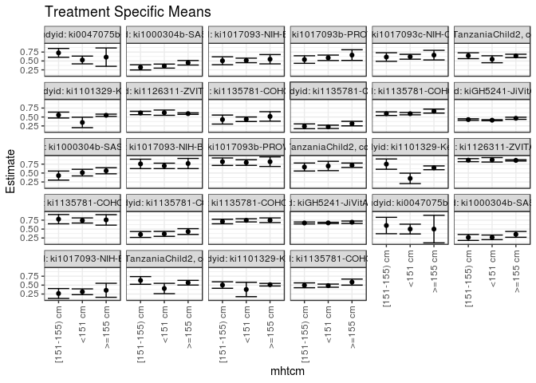

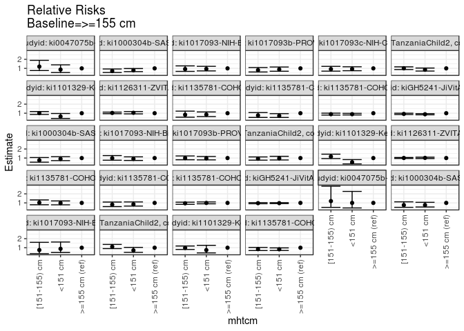

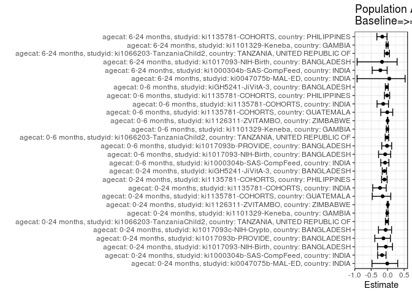

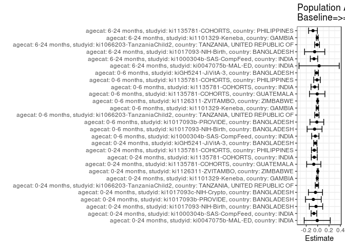

## Results Table

### Parameter: TSM

| agecat | studyid | country | intervention_level | baseline_level | estimate | ci_lower | ci_upper |
| --- | --- | --- | --- | --- | --- | --- | --- |
| 0-24 months | ki0047075b-MAL-ED | INDIA | >=155 cm | NA | 0.6071723 | 0.3499724 | 0.8643721 |
| 0-24 months | ki0047075b-MAL-ED | INDIA | <151 cm | NA | 0.5273843 | 0.4188169 | 0.6359517 |
| 0-24 months | ki0047075b-MAL-ED | INDIA | [151-155) cm | NA | 0.7271571 | 0.6034990 | 0.8508153 |
| 0-24 months | ki1000304b-SAS-CompFeed | INDIA | >=155 cm | NA | 0.4496149 | 0.3861990 | 0.5130308 |
| 0-24 months | ki1000304b-SAS-CompFeed | INDIA | <151 cm | NA | 0.3563123 | 0.2996386 | 0.4129860 |
| 0-24 months | ki1000304b-SAS-CompFeed | INDIA | [151-155) cm | NA | 0.3204874 | 0.2477724 | 0.3932024 |
| 0-24 months | ki1017093-NIH-Birth | BANGLADESH | >=155 cm | NA | 0.5486551 | 0.4182336 | 0.6790767 |
| 0-24 months | ki1017093-NIH-Birth | BANGLADESH | <151 cm | NA | 0.5146639 | 0.4510043 | 0.5783235 |
| 0-24 months | ki1017093-NIH-Birth | BANGLADESH | [151-155) cm | NA | 0.5059378 | 0.3947235 | 0.6171520 |
| 0-24 months | ki1017093b-PROVIDE | BANGLADESH | >=155 cm | NA | 0.6646859 | 0.5146810 | 0.8146908 |
| 0-24 months | ki1017093b-PROVIDE | BANGLADESH | <151 cm | NA | 0.5887756 | 0.5123250 | 0.6652262 |
| 0-24 months | ki1017093b-PROVIDE | BANGLADESH | [151-155) cm | NA | 0.5390640 | 0.4332445 | 0.6448835 |
| 0-24 months | ki1017093c-NIH-Crypto | BANGLADESH | >=155 cm | NA | 0.6637436 | 0.5282693 | 0.7992180 |
| 0-24 months | ki1017093c-NIH-Crypto | BANGLADESH | <151 cm | NA | 0.6180512 | 0.5495847 | 0.6865178 |
| 0-24 months | ki1017093c-NIH-Crypto | BANGLADESH | [151-155) cm | NA | 0.6102192 | 0.4904417 | 0.7299968 |
| 0-24 months | ki1066203-TanzaniaChild2 | TANZANIA, UNITED REPUBLIC OF | >=155 cm | NA | 0.6412225 | 0.5937892 | 0.6886558 |
| 0-24 months | ki1066203-TanzaniaChild2 | TANZANIA, UNITED REPUBLIC OF | <151 cm | NA | 0.5477397 | 0.4501708 | 0.6453085 |
| 0-24 months | ki1066203-TanzaniaChild2 | TANZANIA, UNITED REPUBLIC OF | [151-155) cm | NA | 0.6470618 | 0.5651620 | 0.7289617 |
| 0-24 months | ki1101329-Keneba | GAMBIA | >=155 cm | NA | 0.5487033 | 0.5172264 | 0.5801803 |
| 0-24 months | ki1101329-Keneba | GAMBIA | <151 cm | NA | 0.3474118 | 0.2007707 | 0.4940530 |
| 0-24 months | ki1101329-Keneba | GAMBIA | [151-155) cm | NA | 0.5548053 | 0.4721622 | 0.6374485 |
| 0-24 months | ki1126311-ZVITAMBO | ZIMBABWE | >=155 cm | NA | 0.5945370 | 0.5734749 | 0.6155991 |
| 0-24 months | ki1126311-ZVITAMBO | ZIMBABWE | <151 cm | NA | 0.6214482 | 0.5479254 | 0.6949710 |
| 0-24 months | ki1126311-ZVITAMBO | ZIMBABWE | [151-155) cm | NA | 0.6127404 | 0.5654998 | 0.6599811 |
| 0-24 months | ki1135781-COHORTS | GUATEMALA | >=155 cm | NA | 0.5156234 | 0.3821666 | 0.6490803 |
| 0-24 months | ki1135781-COHORTS | GUATEMALA | <151 cm | NA | 0.4371647 | 0.3738982 | 0.5004312 |
| 0-24 months | ki1135781-COHORTS | GUATEMALA | [151-155) cm | NA | 0.4279687 | 0.3017161 | 0.5542213 |
| 0-24 months | ki1135781-COHORTS | INDIA | >=155 cm | NA | 0.3148926 | 0.2515243 | 0.3782609 |
| 0-24 months | ki1135781-COHORTS | INDIA | <151 cm | NA | 0.2240767 | 0.1773322 | 0.2708211 |
| 0-24 months | ki1135781-COHORTS | INDIA | [151-155) cm | NA | 0.2388092 | 0.1715647 | 0.3060538 |

[output cut: 54 more lines]

### Parameter: E(Y)

| agecat | studyid | country | intervention_level | baseline_level | estimate | ci_lower | ci_upper |
| --- | --- | --- | --- | --- | --- | --- | --- |
| 0-24 months | ki0047075b-MAL-ED | INDIA | NA | NA | 0.6000000 | 0.5192868 | 0.6807132 |
| 0-24 months | ki1000304b-SAS-CompFeed | INDIA | NA | NA | 0.3844086 | 0.3477135 | 0.4211037 |
| 0-24 months | ki1017093-NIH-Birth | BANGLADESH | NA | NA | 0.5201900 | 0.4695846 | 0.5707955 |
| 0-24 months | ki1017093b-PROVIDE | BANGLADESH | NA | NA | 0.5894040 | 0.5323948 | 0.6464131 |
| 0-24 months | ki1017093c-NIH-Crypto | BANGLADESH | NA | NA | 0.6258065 | 0.5718723 | 0.6797406 |
| 0-24 months | ki1066203-TanzaniaChild2 | TANZANIA, UNITED REPUBLIC OF | NA | NA | 0.6283688 | 0.5905159 | 0.6662217 |
| 0-24 months | ki1101329-Keneba | GAMBIA | NA | NA | 0.5422222 | 0.5133413 | 0.5711031 |
| 0-24 months | ki1126311-ZVITAMBO | ZIMBABWE | NA | NA | 0.5971546 | 0.5785503 | 0.6157590 |
| 0-24 months | ki1135781-COHORTS | GUATEMALA | NA | NA | 0.4477212 | 0.3954919 | 0.4999504 |
| 0-24 months | ki1135781-COHORTS | INDIA | NA | NA | 0.2557143 | 0.2227697 | 0.2886589 |
| 0-24 months | ki1135781-COHORTS | PHILIPPINES | NA | NA | 0.6068680 | 0.5823645 | 0.6313715 |
| 0-24 months | kiGH5241-JiVitA-3 | BANGLADESH | NA | NA | 0.4228321 | 0.4116868 | 0.4339775 |
| 0-6 months | ki1000304b-SAS-CompFeed | INDIA | NA | NA | 0.5228758 | 0.4664267 | 0.5793250 |
| 0-6 months | ki1017093-NIH-Birth | BANGLADESH | NA | NA | 0.7130045 | 0.6535890 | 0.7724200 |
| 0-6 months | ki1017093b-PROVIDE | BANGLADESH | NA | NA | 0.8044693 | 0.7471161 | 0.8618224 |
| 0-6 months | ki1066203-TanzaniaChild2 | TANZANIA, UNITED REPUBLIC OF | NA | NA | 0.7053571 | 0.6558827 | 0.7548316 |
| 0-6 months | ki1101329-Keneba | GAMBIA | NA | NA | 0.6415094 | 0.5927496 | 0.6902692 |
| 0-6 months | ki1126311-ZVITAMBO | ZIMBABWE | NA | NA | 0.8543527 | 0.8380828 | 0.8706225 |
| 0-6 months | ki1135781-COHORTS | GUATEMALA | NA | NA | 0.7500000 | 0.6917133 | 0.8082867 |
| 0-6 months | ki1135781-COHORTS | INDIA | NA | NA | 0.3800425 | 0.3361595 | 0.4239255 |
| 0-6 months | ki1135781-COHORTS | PHILIPPINES | NA | NA | 0.7367021 | 0.7051294 | 0.7682749 |
| 0-6 months | kiGH5241-JiVitA-3 | BANGLADESH | NA | NA | 0.6759220 | 0.6625668 | 0.6892772 |
| 6-24 months | ki0047075b-MAL-ED | INDIA | NA | NA | 0.5263158 | 0.4116286 | 0.6410029 |
| 6-24 months | ki1000304b-SAS-CompFeed | INDIA | NA | NA | 0.2876712 | 0.2441703 | 0.3311721 |
| 6-24 months | ki1017093-NIH-Birth | BANGLADESH | NA | NA | 0.3030303 | 0.2377927 | 0.3682679 |
| 6-24 months | ki1066203-TanzaniaChild2 | TANZANIA, UNITED REPUBLIC OF | NA | NA | 0.5582656 | 0.5057575 | 0.6107737 |
| 6-24 months | ki1101329-Keneba | GAMBIA | NA | NA | 0.5045965 | 0.4711801 | 0.5380129 |
| 6-24 months | ki1135781-COHORTS | PHILIPPINES | NA | NA | 0.5026681 | 0.4688378 | 0.5364984 |

### Parameter: RR

| agecat | studyid | country | intervention_level | baseline_level | estimate | ci_lower | ci_upper |
| --- | --- | --- | --- | --- | --- | --- | --- |
| 0-24 months | ki0047075b-MAL-ED | INDIA | >=155 cm | >=155 cm | 1.0000000 | 1.0000000 | 1.0000000 |
| 0-24 months | ki0047075b-MAL-ED | INDIA | <151 cm | >=155 cm | 0.8685909 | 0.5426448 | 1.3903203 |
| 0-24 months | ki0047075b-MAL-ED | INDIA | [151-155) cm | >=155 cm | 1.1976125 | 0.7597840 | 1.8877414 |
| 0-24 months | ki1000304b-SAS-CompFeed | INDIA | >=155 cm | >=155 cm | 1.0000000 | 1.0000000 | 1.0000000 |
| 0-24 months | ki1000304b-SAS-CompFeed | INDIA | <151 cm | >=155 cm | 0.7924833 | 0.6410580 | 0.9796770 |
| 0-24 months | ki1000304b-SAS-CompFeed | INDIA | [151-155) cm | >=155 cm | 0.7128042 | 0.5457925 | 0.9309212 |
| 0-24 months | ki1017093-NIH-Birth | BANGLADESH | >=155 cm | >=155 cm | 1.0000000 | 1.0000000 | 1.0000000 |
| 0-24 months | ki1017093-NIH-Birth | BANGLADESH | <151 cm | >=155 cm | 0.9380463 | 0.7174402 | 1.2264868 |
| 0-24 months | ki1017093-NIH-Birth | BANGLADESH | [151-155) cm | >=155 cm | 0.9221417 | 0.6670051 | 1.2748708 |
| 0-24 months | ki1017093b-PROVIDE | BANGLADESH | >=155 cm | >=155 cm | 1.0000000 | 1.0000000 | 1.0000000 |
| 0-24 months | ki1017093b-PROVIDE | BANGLADESH | <151 cm | >=155 cm | 0.8857952 | 0.6822198 | 1.1501177 |
| 0-24 months | ki1017093b-PROVIDE | BANGLADESH | [151-155) cm | >=155 cm | 0.8110056 | 0.6010335 | 1.0943318 |
| 0-24 months | ki1017093c-NIH-Crypto | BANGLADESH | >=155 cm | >=155 cm | 1.0000000 | 1.0000000 | 1.0000000 |
| 0-24 months | ki1017093c-NIH-Crypto | BANGLADESH | <151 cm | >=155 cm | 0.9311596 | 0.7378615 | 1.1750961 |
| 0-24 months | ki1017093c-NIH-Crypto | BANGLADESH | [151-155) cm | >=155 cm | 0.9193598 | 0.6924659 | 1.2205980 |
| 0-24 months | ki1066203-TanzaniaChild2 | TANZANIA, UNITED REPUBLIC OF | >=155 cm | >=155 cm | 1.0000000 | 1.0000000 | 1.0000000 |
| 0-24 months | ki1066203-TanzaniaChild2 | TANZANIA, UNITED REPUBLIC OF | <151 cm | >=155 cm | 0.8542116 | 0.7043425 | 1.0359696 |
| 0-24 months | ki1066203-TanzaniaChild2 | TANZANIA, UNITED REPUBLIC OF | [151-155) cm | >=155 cm | 1.0091066 | 0.8713833 | 1.1685972 |
| 0-24 months | ki1101329-Keneba | GAMBIA | >=155 cm | >=155 cm | 1.0000000 | 1.0000000 | 1.0000000 |
| 0-24 months | ki1101329-Keneba | GAMBIA | <151 cm | >=155 cm | 0.6331506 | 0.4135249 | 0.9694210 |
| 0-24 months | ki1101329-Keneba | GAMBIA | [151-155) cm | >=155 cm | 1.0111208 | 0.8619133 | 1.1861578 |
| 0-24 months | ki1126311-ZVITAMBO | ZIMBABWE | >=155 cm | >=155 cm | 1.0000000 | 1.0000000 | 1.0000000 |
| 0-24 months | ki1126311-ZVITAMBO | ZIMBABWE | <151 cm | >=155 cm | 1.0452642 | 0.9238188 | 1.1826749 |
| 0-24 months | ki1126311-ZVITAMBO | ZIMBABWE | [151-155) cm | >=155 cm | 1.0306179 | 0.9467502 | 1.1219150 |
| 0-24 months | ki1135781-COHORTS | GUATEMALA | >=155 cm | >=155 cm | 1.0000000 | 1.0000000 | 1.0000000 |
| 0-24 months | ki1135781-COHORTS | GUATEMALA | <151 cm | >=155 cm | 0.8478370 | 0.6305190 | 1.1400572 |
| 0-24 months | ki1135781-COHORTS | GUATEMALA | [151-155) cm | >=155 cm | 0.8300024 | 0.5610070 | 1.2279773 |
| 0-24 months | ki1135781-COHORTS | INDIA | >=155 cm | >=155 cm | 1.0000000 | 1.0000000 | 1.0000000 |
| 0-24 months | ki1135781-COHORTS | INDIA | <151 cm | >=155 cm | 0.7115971 | 0.5323903 | 0.9511264 |
| 0-24 months | ki1135781-COHORTS | INDIA | [151-155) cm | >=155 cm | 0.7583831 | 0.5363817 | 1.0722681 |

[output cut: 54 more lines]

### Parameter: PAR

| agecat | studyid | country | intervention_level | baseline_level | estimate | ci_lower | ci_upper |
| --- | --- | --- | --- | --- | --- | --- | --- |
| 0-24 months | ki0047075b-MAL-ED | INDIA | >=155 cm | NA | -0.0071723 | -0.2362625 | 0.2219179 |
| 0-24 months | ki1000304b-SAS-CompFeed | INDIA | >=155 cm | NA | -0.0652063 | -0.1143550 | -0.0160576 |
| 0-24 months | ki1017093-NIH-Birth | BANGLADESH | >=155 cm | NA | -0.0284651 | -0.1462152 | 0.0892850 |
| 0-24 months | ki1017093b-PROVIDE | BANGLADESH | >=155 cm | NA | -0.0752819 | -0.2138649 | 0.0633010 |
| 0-24 months | ki1017093c-NIH-Crypto | BANGLADESH | >=155 cm | NA | -0.0379372 | -0.1617945 | 0.0859201 |
| 0-24 months | ki1066203-TanzaniaChild2 | TANZANIA, UNITED REPUBLIC OF | >=155 cm | NA | -0.0128537 | -0.0420007 | 0.0162932 |
| 0-24 months | ki1101329-Keneba | GAMBIA | >=155 cm | NA | -0.0064811 | -0.0197481 | 0.0067859 |
| 0-24 months | ki1126311-ZVITAMBO | ZIMBABWE | >=155 cm | NA | 0.0026176 | -0.0068906 | 0.0121259 |
| 0-24 months | ki1135781-COHORTS | GUATEMALA | >=155 cm | NA | -0.0679023 | -0.1922329 | 0.0564283 |
| 0-24 months | ki1135781-COHORTS | INDIA | >=155 cm | NA | -0.0591783 | -0.1113765 | -0.0069801 |
| 0-24 months | ki1135781-COHORTS | PHILIPPINES | >=155 cm | NA | -0.0584684 | -0.1087948 | -0.0081420 |
| 0-24 months | kiGH5241-JiVitA-3 | BANGLADESH | >=155 cm | NA | -0.0411714 | -0.0686445 | -0.0136983 |
| 0-6 months | ki1000304b-SAS-CompFeed | INDIA | >=155 cm | NA | -0.0407660 | -0.1052336 | 0.0237017 |
| 0-6 months | ki1017093-NIH-Birth | BANGLADESH | >=155 cm | NA | -0.0537292 | -0.1844179 | 0.0769594 |
| 0-6 months | ki1017093b-PROVIDE | BANGLADESH | >=155 cm | NA | -0.0137125 | -0.1347982 | 0.1073731 |
| 0-6 months | ki1066203-TanzaniaChild2 | TANZANIA, UNITED REPUBLIC OF | >=155 cm | NA | -0.0132419 | -0.0506487 | 0.0241648 |
| 0-6 months | ki1101329-Keneba | GAMBIA | >=155 cm | NA | -0.0047928 | -0.0259744 | 0.0163887 |
| 0-6 months | ki1126311-ZVITAMBO | ZIMBABWE | >=155 cm | NA | -0.0006880 | -0.0092831 | 0.0079072 |
| 0-6 months | ki1135781-COHORTS | GUATEMALA | >=155 cm | NA | -0.0075758 | -0.1429684 | 0.1278169 |
| 0-6 months | ki1135781-COHORTS | INDIA | >=155 cm | NA | -0.0508112 | -0.1169126 | 0.0152902 |
| 0-6 months | ki1135781-COHORTS | PHILIPPINES | >=155 cm | NA | -0.0107326 | -0.0689994 | 0.0475343 |
| 0-6 months | kiGH5241-JiVitA-3 | BANGLADESH | >=155 cm | NA | -0.0159896 | -0.0465165 | 0.0145372 |
| 6-24 months | ki0047075b-MAL-ED | INDIA | >=155 cm | NA | 0.0263158 | -0.3268414 | 0.3794730 |
| 6-24 months | ki1000304b-SAS-CompFeed | INDIA | >=155 cm | NA | -0.0635873 | -0.1285716 | 0.0013970 |
| 6-24 months | ki1017093-NIH-Birth | BANGLADESH | >=155 cm | NA | -0.0519592 | -0.2295997 | 0.1256813 |
| 6-24 months | ki1066203-TanzaniaChild2 | TANZANIA, UNITED REPUBLIC OF | >=155 cm | NA | -0.0094260 | -0.0513261 | 0.0324740 |
| 6-24 months | ki1101329-Keneba | GAMBIA | >=155 cm | NA | -0.0070860 | -0.0225191 | 0.0083471 |
| 6-24 months | ki1135781-COHORTS | PHILIPPINES | >=155 cm | NA | -0.0818588 | -0.1590904 | -0.0046272 |

### Parameter: PAF

| agecat | studyid | country | intervention_level | baseline_level | estimate | ci_lower | ci_upper |
| --- | --- | --- | --- | --- | --- | --- | --- |
| 0-24 months | ki0047075b-MAL-ED | INDIA | >=155 cm | NA | -0.0119538 | -0.4753356 | 0.3058864 |
| 0-24 months | ki1000304b-SAS-CompFeed | INDIA | >=155 cm | NA | -0.1696276 | -0.3045774 | -0.0486374 |
| 0-24 months | ki1017093-NIH-Birth | BANGLADESH | >=155 cm | NA | -0.0547206 | -0.3069599 | 0.1488373 |
| 0-24 months | ki1017093b-PROVIDE | BANGLADESH | >=155 cm | NA | -0.1277255 | -0.3895115 | 0.0847396 |
| 0-24 months | ki1017093c-NIH-Crypto | BANGLADESH | >=155 cm | NA | -0.0606213 | -0.2782420 | 0.1199496 |
| 0-24 months | ki1066203-TanzaniaChild2 | TANZANIA, UNITED REPUBLIC OF | >=155 cm | NA | -0.0204557 | -0.0679472 | 0.0249239 |
| 0-24 months | ki1101329-Keneba | GAMBIA | >=155 cm | NA | -0.0119529 | -0.0367438 | 0.0122453 |
| 0-24 months | ki1126311-ZVITAMBO | ZIMBABWE | >=155 cm | NA | 0.0043835 | -0.0116704 | 0.0201827 |
| 0-24 months | ki1135781-COHORTS | GUATEMALA | >=155 cm | NA | -0.1516620 | -0.4670657 | 0.0959333 |
| 0-24 months | ki1135781-COHORTS | INDIA | >=155 cm | NA | -0.2314235 | -0.4539107 | -0.0429827 |
| 0-24 months | ki1135781-COHORTS | PHILIPPINES | >=155 cm | NA | -0.0963446 | -0.1825945 | -0.0163852 |
| 0-24 months | kiGH5241-JiVitA-3 | BANGLADESH | >=155 cm | NA | -0.0973705 | -0.1643042 | -0.0342846 |
| 0-6 months | ki1000304b-SAS-CompFeed | INDIA | >=155 cm | NA | -0.0779649 | -0.2089807 | 0.0388528 |
| 0-6 months | ki1017093-NIH-Birth | BANGLADESH | >=155 cm | NA | -0.0753561 | -0.2754685 | 0.0933600 |
| 0-6 months | ki1017093b-PROVIDE | BANGLADESH | >=155 cm | NA | -0.0170455 | -0.1792690 | 0.1228621 |
| 0-6 months | ki1066203-TanzaniaChild2 | TANZANIA, UNITED REPUBLIC OF | >=155 cm | NA | -0.0187734 | -0.0732553 | 0.0329428 |
| 0-6 months | ki1101329-Keneba | GAMBIA | >=155 cm | NA | -0.0074712 | -0.0410345 | 0.0250101 |
| 0-6 months | ki1126311-ZVITAMBO | ZIMBABWE | >=155 cm | NA | -0.0008052 | -0.0109163 | 0.0092047 |
| 0-6 months | ki1135781-COHORTS | GUATEMALA | >=155 cm | NA | -0.0101010 | -0.2077661 | 0.1552139 |
| 0-6 months | ki1135781-COHORTS | INDIA | >=155 cm | NA | -0.1336988 | -0.3217145 | 0.0275715 |
| 0-6 months | ki1135781-COHORTS | PHILIPPINES | >=155 cm | NA | -0.0145684 | -0.0968538 | 0.0615440 |
| 0-6 months | kiGH5241-JiVitA-3 | BANGLADESH | >=155 cm | NA | -0.0236560 | -0.0698383 | 0.0205327 |
| 6-24 months | ki0047075b-MAL-ED | INDIA | >=155 cm | NA | 0.0500000 | -0.9284701 | 0.5320125 |
| 6-24 months | ki1000304b-SAS-CompFeed | INDIA | >=155 cm | NA | -0.2210416 | -0.4683273 | -0.0154021 |
| 6-24 months | ki1017093-NIH-Birth | BANGLADESH | >=155 cm | NA | -0.1714653 | -0.9271579 | 0.2878991 |
| 6-24 months | ki1066203-TanzaniaChild2 | TANZANIA, UNITED REPUBLIC OF | >=155 cm | NA | -0.0168845 | -0.0948706 | 0.0555467 |
| 6-24 months | ki1101329-Keneba | GAMBIA | >=155 cm | NA | -0.0140429 | -0.0451286 | 0.0161183 |
| 6-24 months | ki1135781-COHORTS | PHILIPPINES | >=155 cm | NA | -0.1628486 | -0.3273014 | -0.0187715 |